# Midterm Tutorial 2

Grace Wysocki

3/7/2022

Mini-Tutorial 2: Mapping (15 points)

Topics to Cover: -Either mapping with the maps package OR mapping from a shapefile.

Mapping is a way to visualize data patterns across a certain space. This can be done in R using packages such as maps and leaflet. You can see mapping in data visualization on things such as a map of the United States, specific regions using functions such as geom_sf or even the world map, the mapping possibilities are endless!

I am using the county function from the maps package. This allow you to make a map of the United States that has the county lines in each state across the country drawn. Then I loaded in a data set from the United State Census Bureau I named County_census00-01 that, gives the U.S. census results from the years 2000-2001. The variables that I plan to use include the April 1, 2000 Census(which is the population census from April 1, 2000) and Area Name (which is the county names).

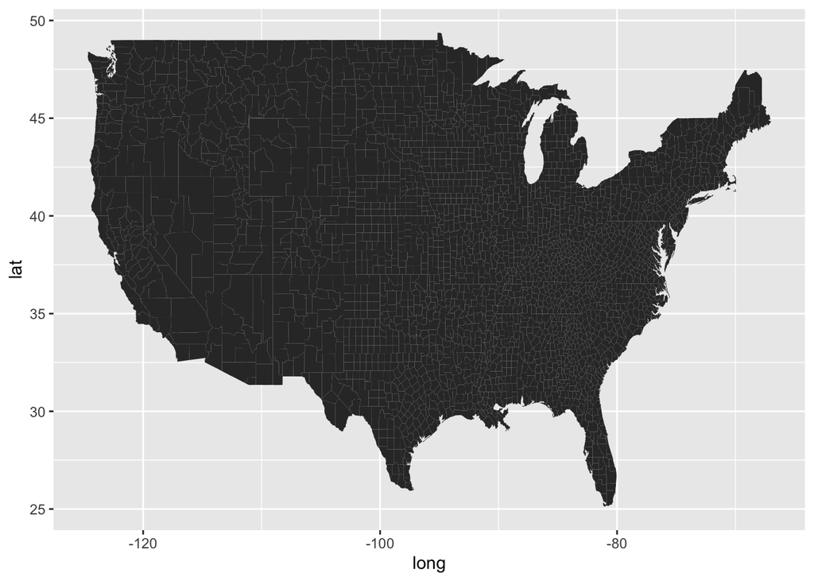

```r
##install.packages("maps")
library(maps)
library(tidyverse)
library(ggplot2)

library(readr)
county_census <- read_csv("data/County_census00-01.csv") #load in data
#View(county_census)

county_df <- ggplot2::map_data("county") #load in county package from maps
#view(county_df)
ggplot(data = county_df,
            mapping = aes(x = long, y = lat,
                          group = group)) +
  geom_polygon()
```

```r
#creates a map of the United State using the map data from  county_df
```

Here you can see that I created a map of the United States, excluding Hawaii and Alaska, that show every individual county within each state. Presented also is the corresponding latitude and longitude lines.

```r
us_full <- left_join(county_df, county_census, by = c("subregion" = "Area Name")) %>% mutate(April_census = "April 1, 2000 Census")

#ggplot(data = us_full, aes(x = long, y = lat, group = group)) +
  #geom_polygon(colour = "black", aes(fill = "April_census" )) +
  #coord_map(projection = "albers", lat0 = 39, lat1 = 45) +
  ##theme_void() +
  #scale_fill_viridis_b()
```

Here I attempted to create graph that would have been colored by state counties, with corresponding value of census population. Unfortunately I was unable to correctly complete the code, but I was able to join the country_df and county_census data frames so that it is ready to be graphed.